# Univariate Bayesian time series models

2 May 2023

## Overview of today’s material

- Bayesian estimation
- Overview of Stan
- Manipulating and plotting Stan output
- Examples of time series models

## Review of models we’ve used so far

### Models

- Regression
- ARMA models
- State Space Models
- Dynamic Linear Models
- Dynamic Factor Analysis
- Multivariate time series models)

## Why Bayesian?

- Complex hierarchical models
  - Non-linear models
  - Hierarchical or shared parameters
  - Non-normal data
  - Prior information
- Inference: what’s the probability that the data are less than some threshold?
- No bootstrapping!
  - We get credible intervals for parameters and states simultaneously

## Bayesian logic

- Conditional probability

\[P({\theta}|\textbf{y})P(\textbf{y})=P(\theta)P(\textbf{y}|\theta)\]

\[P({\theta}|\textbf{y})=\frac{P(\theta)P(\textbf{y}|\theta)}{P(\textbf{y})}\]

- \({P(\textbf{y})}\) is a normalizing constant that we often don’t have to worry about

## Bayesian logic

- Parameters are random, data are fixed
- \[P({\theta}|\textbf{y})=P(\theta)P(\textbf{y}|\theta)\]
- \(P({\theta}|\textbf{y})\) is the posterior
- \(P(\textbf{y}|\theta)\) is the likelihood
- \(P(\theta)\) is the prior

## Bayesian logic

[figure not shown]

## Bayesian logic

- Difference between posterior and prior represents how much we learn by collecting data
- Experiment {H, H, T, H, H, T, H, H}

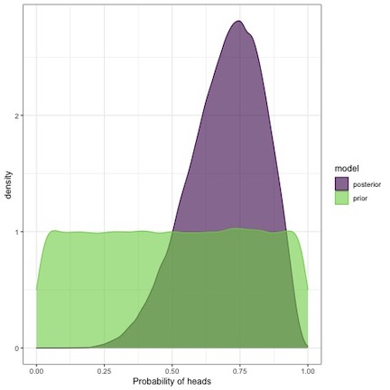

## Bayesian mechanics

- MLE seeks to find the combination of parameters that maximize the likelihood (e.g. find absolute best point)
- Bayesian estimation uses integration to find the combination of parameters that are best *on average*

## Bayesian mechanics in practice

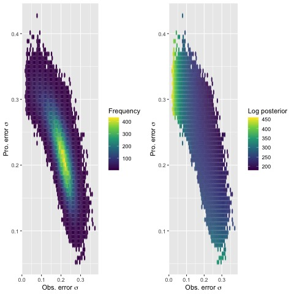

## Estimation

- Goal of Bayesian estimation in drawing samples from the posterior \(P({\theta}|\textbf{y})\)
- For very simple models, we can write the analytical solution for the posterior
- But for 99% of the problems we work on, need to generate samples via simulation
- Markov chain Monte Carlo

## Estimation

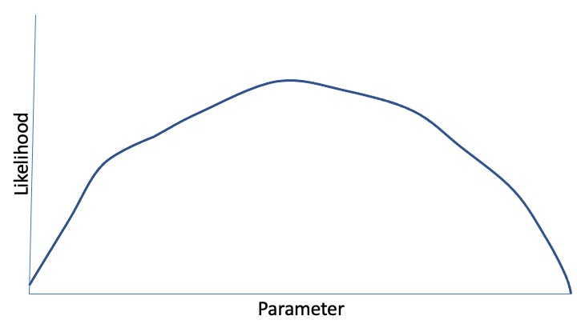

## Estimation

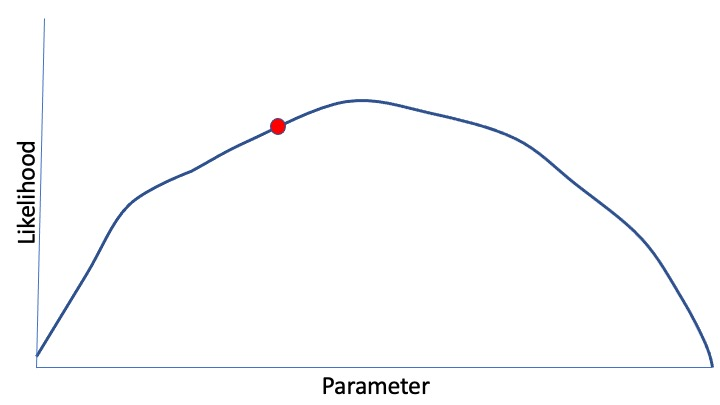

## Estimation

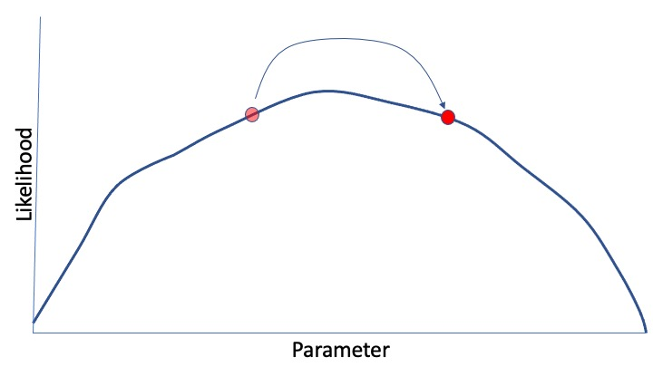

## Estimation

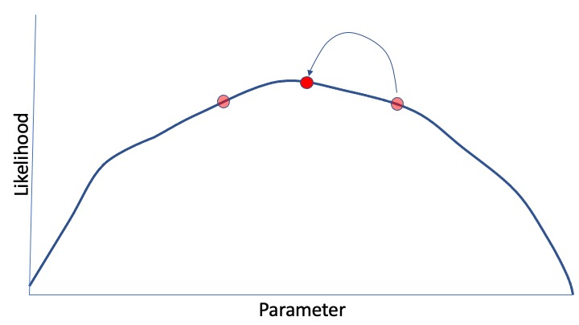

## Estimation

- Thousands of proposals later, we have a MCMC chain

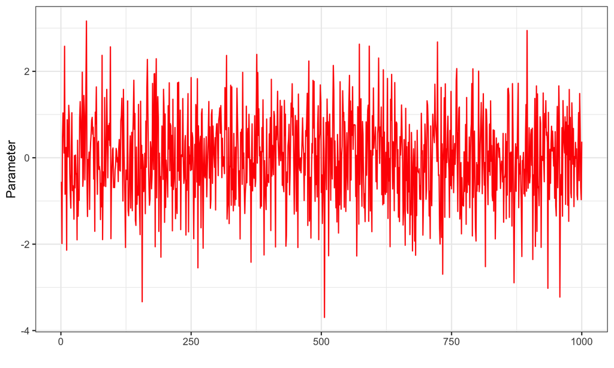

## Estimation: best practices

- Run 3-4 MCMC chains in parallel
- Discard first ~ 10-50% of each MCMC chain as a ‘burn-in’
- Optionally apply MCMC thinning to reduce autocorrelation

## Lots of algorithms for sampling

- Metropolis, Metropolis-Hastings
- Sampling - Imporance - Resampling (SIR)
- No-U-Turn Sampler (NUTS)
- [Monahan et al. 2016, Faster estimation of Bayesian models in ecology using Hamiltonian Monte Carlo](https://besjournals.onlinelibrary.wiley.com/doi/abs/10.1111/2041-210X.12681)

## What is Stan?

- Powerful, cross-platform and cross-language (R, Julia, Matlab, etc) that allows users to write custom code that can be called directly from R
- Estimation can be fully or approximate Bayesian inference, or maximum a posteriori optimization (BFGS)
- Useful links:
  - [Stan homepage](https://mc-stan.org/)
  - [Stan manual](https://mc-stan.org/users/documentation/)
  - [rstan](https://cran.r-project.org/web/packages/rstan/index.html)

## Options for using Stan in this class

- Write your own code (based on examples in the manual, etc)
- Use an existing package
- Use our bundled code to get started with simple models (we’ll start here)

## Existing packages: rstanarm and brms

- Both packages very flexible, and allow same syntax as basic lm/glm or lmer models, e.g.

```r
rstan::stan_lm
rstan::stan_glm
rstan::stan_glmer
```

- Vignettes [brms](http://paul-buerkner.github.io/brms/) [rstanarm](http://mc-stan.org/rstanarm/articles/rstanarm.html)

## Existing packages: rstanarm and brms

- Very flexible `brms` includes autocorrelated errors, non-normal data, non-linear smooths (GAMs), etc.
- Limitations related to this class:
- allows multivariate data, but not multivariate time series models [brms example](https://cran.r-project.org/web/packages/brms/vignettes/brms_multivariate.html)

## Existing packages: rstanarm and brms

`brms` offers notation that should be very familiar to run many classes of models,

```r
brms::brm(y ~ x * z + (1|group), data=d)
brms::brm(y01 ~ x * z + (1|group), data=d,
          family = binomial("logit"))
brms::brm(bf(y ~ s(x)), data=d)
```

- smooths can also be of 2-d models (e.g. spatial models)

## Existing packages: rstanarm and brms

`brms` allows ARMA correlation structures that we’re familiar with,

```r
data("LakeHuron")
LakeHuron <- as.data.frame(LakeHuron)
fit <- brm(x ~ arma(p = 2, q = 1),
           data = LakeHuron)
```

- also includes spatial models (car, sar)
- does not include these in the context of state space models

## Example: linear regression in brms

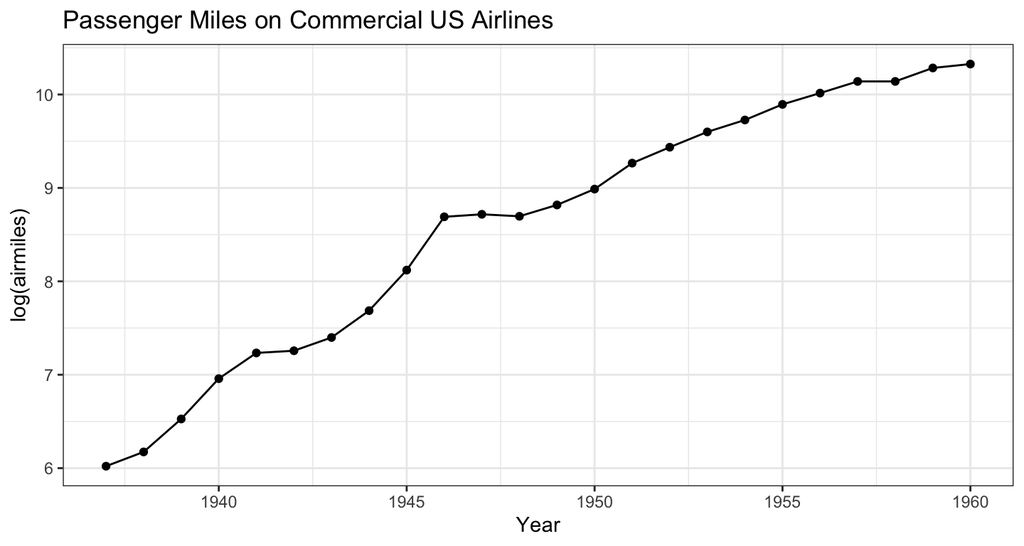

## Example: linear regression and AR(1) models in brms

- Regression

```r
lm_fit = brms::brm(log(airmiles) ~ year, data=df)
```

- Question: how would we change the code to be an AR(1) model?

```r
lm_ar= brms::brm(log(airmiles) ~ arma(p = 1, q = 0),
                 data=df)
```

- Defaults to 4 MCMC chains, 2000 iterations, 1000 burn-in

## Example: linear regression and AR(1) models in brms

- `lm_ar` is a “brmsfit” object and has a bunch of convenient plotting functions

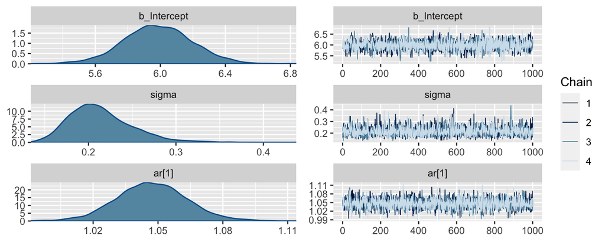

```r
plot(lm_ar)
```

## Example: linear regression and AR(1) models in brms

- Pairs plots

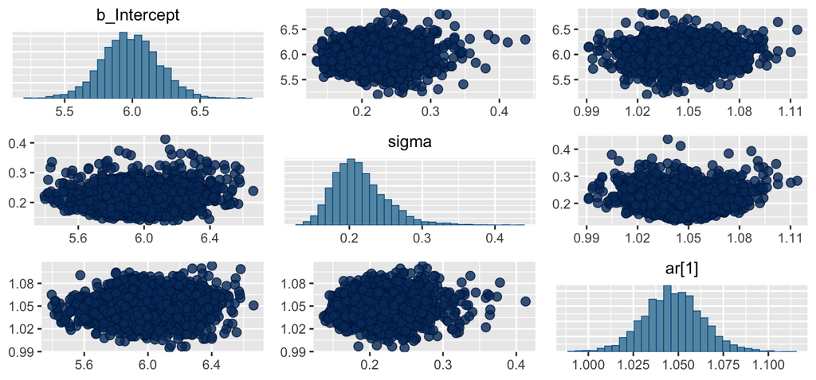

```r
pairs(lm_ar)
```

## Example: linear regression and AR(1) models in brms

- Posterior predictive checks

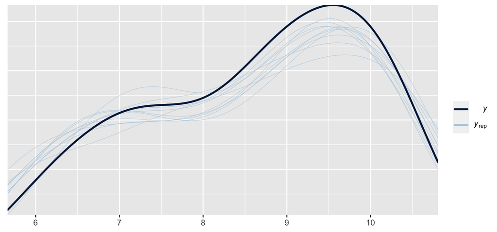

```r
pp_check(lm_ar)
```

## Example: linear regression and AR(1) models in brms

- Shinystan

```r
shinystan::launch_shinystan(lm_ar)
```

## Example: linear regression and AR(1) models in brms

- Additional functionality / diagnostics in `bayesplot`

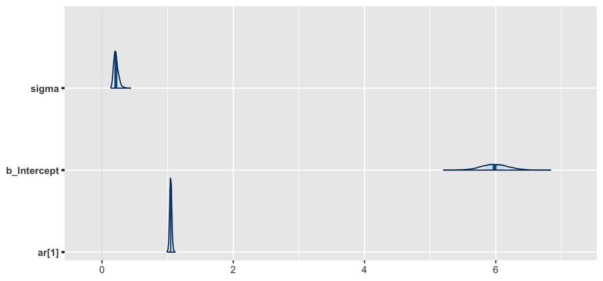

```r
mcmc_areas(lm_ar,c("sigma","b_Intercept","ar[1]"))
```

## Plotting with Stan output

These plots only the tip of the iceberg for plotting. For more great examples of the kinds of plots avaialable, see these vignettes:

- [Examples on Stan](https://mc-stan.org/users/interfaces/bayesplot)
- [Jonah Gabry’s introduction to bayesplot](https://cran.r-project.org/web/packages/bayesplot/vignettes/plotting-mcmc-draws.html)
- [Matthew Kay’s introduction to bayesplot and tidybayes](https://cran.r-project.org/web/packages/tidybayes/vignettes/tidybayes.html)

## Customized models and code for this class

- We’ll need to install these packages to run Stan,

```r
install.packages("rstan",
                 repos = "https://cloud.r-project.org")
install.packages("devtools",
                 repos = "https://cloud.r-project.org")
```

- And then we can install our custom package for the class with bundled Stan time series models

```r
devtools::install_github(repo="atsa-es/atsar")
library("atsar")
```

## Models included

- `atsar` package includes:
- RW, AR and MA models (with and without drift)
- DLMs (intercept, slope, both)
- State space RW and AR models
- Flexible families for each model

## More time series models: application to NEON EFI Aquatics challenge

- Daily temperature and oxygen data available from Barco Lake in Florida

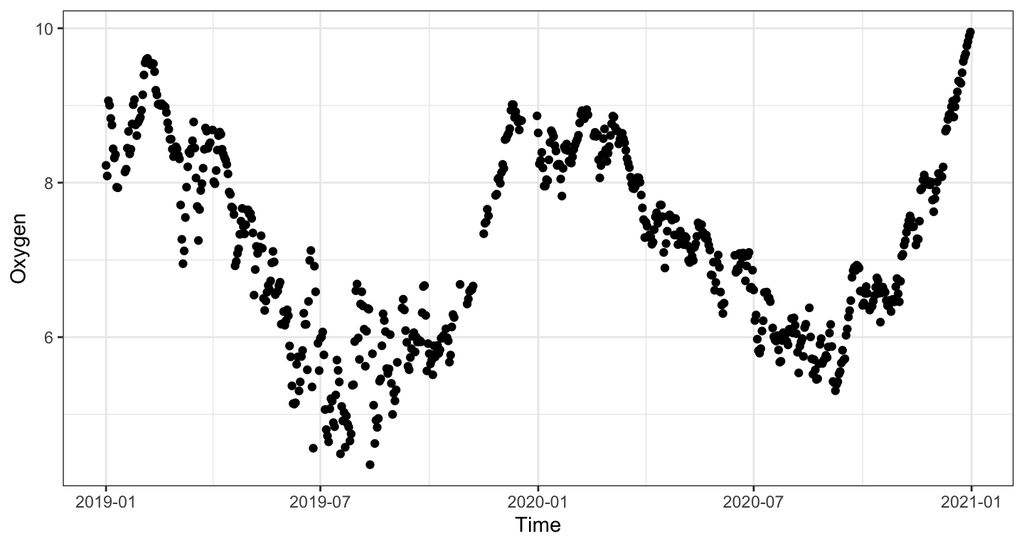

## ‘atsar’ package: random walk and AR(1) models

This model should be familiar,

\[E\left[ { Y }_{ t } \right] =E\left[ { Y }_{ t-1 } \right] +{ e }_{ t-1 }\] * Note that the use of the argument `model_name` and `est_drift`. By not estimating drift, we assume the process is stationary with respect to the mean

```r
rw = fit_stan(y = neon$oxygen,
              est_drift = FALSE, model_name = "rw")
```

## ‘atsar’ package: univariate state space models

- Specify the MCMC parameters

```r
rw = fit_stan(y = neon$oxygen,
              est_drift = FALSE,
              model_name = "rw",
              mcmc_list = list(n_mcmc = 2000,
              n_burn = 500,
              n_chain = 3,
              n_thin = 1))
```

## ‘atsar’ package: univariate state space models

State equation: \[{ x }_{ t }={ \phi x }_{ t-1 }+{ \varepsilon }_{ t-1 }\] where \({ \varepsilon }_{ t-1 } \sim Normal(0, q)\)

Observation equation: \[{ Y }_{ t } \sim Normal(x_{t}, r)\]

- Let’s compare models with and without the AR parameter \(\phi\) in the process model

## ‘atsar’ package: univariate state space models

We can first run the model with \(\phi\),

```r
ss_ar = fit_stan(y = neon$oxygen,
        est_drift=FALSE, model_name = "ss_ar",
        mcmc_list = list(n_mcmc = 2000, n_chain = 1,
                         n_thin = 1,n_burn=1000))
```

then without,

```r
ss_rw = fit_stan(y = neon$oxygen,
        est_drift=FALSE, model_name = "ss_rw",
        mcmc_list = list(n_mcmc = 2000, n_chain = 1,
                         n_thin = 1,n_burn=1000))
```

## ‘atsar’ package: univariate state space models

Did the models converge?

- One quick check is to look at the value of R-hat for each parameter (generally should be small, < 1.1 or < 1.05)

```r
rw_summary <- summary(ss_rw, pars = c("sigma_process","sigma_obs"),
                      probs = c(0.1, 0.9))$summary
print(rw_summary)
```

```
##                     mean     se_mean          sd        10%        90%
## sigma_process 0.25050137 0.001921004 0.008951147 0.23891867 0.26150841
## sigma_obs     0.05251124 0.005040720 0.014999464 0.03513455 0.07474426
##                   n_eff     Rhat
## sigma_process 21.712052 1.128660
## sigma_obs      8.854545 1.392187
```

## ‘atsar’ package: univariate state space models

- Calculate maximum Rhat across all parameters,

```r
rhats <- summary(ss_rw)$summary[,"Rhat"]
print(max(rhats))
```

```
## [1] 1.401858
```

## ‘atsar’ package: univariate state space models

- Tidy summaries from Stan output: Using the `broom.mixed` package, we can also extract some tidy summaries of the output

```r
coef = broom.mixed::tidy(ss_ar)
head(coef)
```

```
## # A tibble: 6 × 3
##   term          estimate std.error
##   <chr>            <dbl>     <dbl>
## 1 sigma_process    0.250   0.00845
## 2 pred[1]          8.22    0.0575
## 3 pred[2]          8.14    0.0600
## 4 pred[3]          9.02    0.0578
## 5 pred[4]          8.99    0.0546
## 6 pred[5]          8.84    0.0536
```

## ‘atsar’ package: univariate state space models

- We can use this to look at predictions versus our data

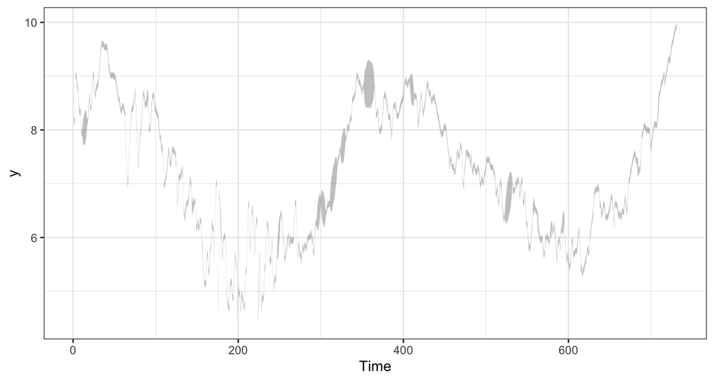

## ‘atsar’ package: univariate state space models

- We can use this to look at predictions versus our data

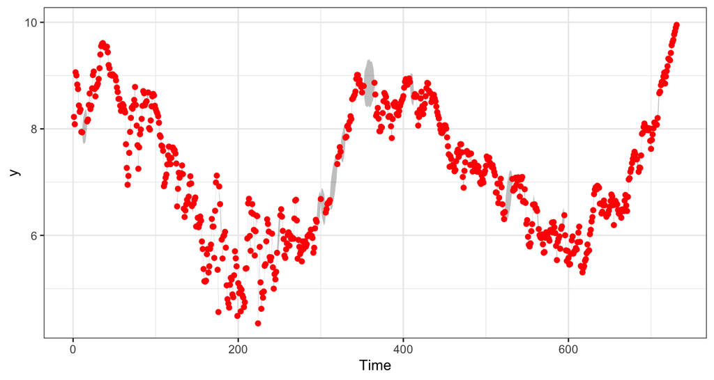

## ‘atsar’ package: univariate state space models

- We can use this to look at predictions versus our data

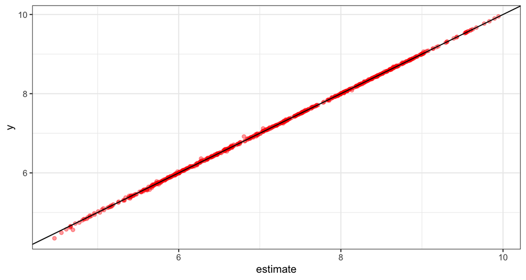

##‘atsar’ package: raw samples

- tidy() functions great at summarizing
- fit_stan() returns ‘stanfit’ object that we can use `rstan::extract()` on to get raw posterior draws, by chain

```r
pars = extract(ss_ar)
```

- returns list of parameters we can access directly, e.g.

```r
summary(pars$sigma_process)
```

##‘atsar’ package: model selection

- Best practice is to use Leave One Out Information Criterion (LOOIC) in `loo` package
- We can compare the LOOIC from the 2 models (AR vs RW)

```
loo_ar = (loo::loo(ss_ar))
loo_rw = (loo::loo(ss_rw))
```

## ‘atsar’ package: DLMs

- For comparison to MARSS, we’ll use Mark’s example of logit-transformed survival from the Columbia River. We can think about setting the DLM up in the slope or the intercept. For this first example, we’ll do the latter.

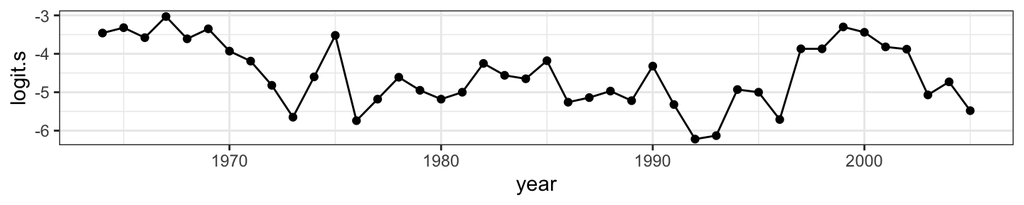

## ‘atsar’ package: DLMs

- Fit DLM with random walk in intercept

```r
mod = fit_stan(y = SalmonSurvCUI$logit.s,
               model_name="dlm-intercept",
               mcmc_list = list(n_mcmc = 2000,
                                n_chain = 1, n_thin = 1,n_burn=1000))
```

- Fit DLM with random walk in slope

```r
mod_slope = fit_stan(y = SalmonSurvCUI$logit.s,
        x = SalmonSurvCUI$CUI.apr,
        model_name="dlm-slope",
        mcmc_list = list(n_mcmc = 2000,
                                n_chain = 1, n_thin = 1,n_burn=1000))
```

## ‘atsar’ package: DLMs

Let’s look at predictions using the `rstan::extract()` function

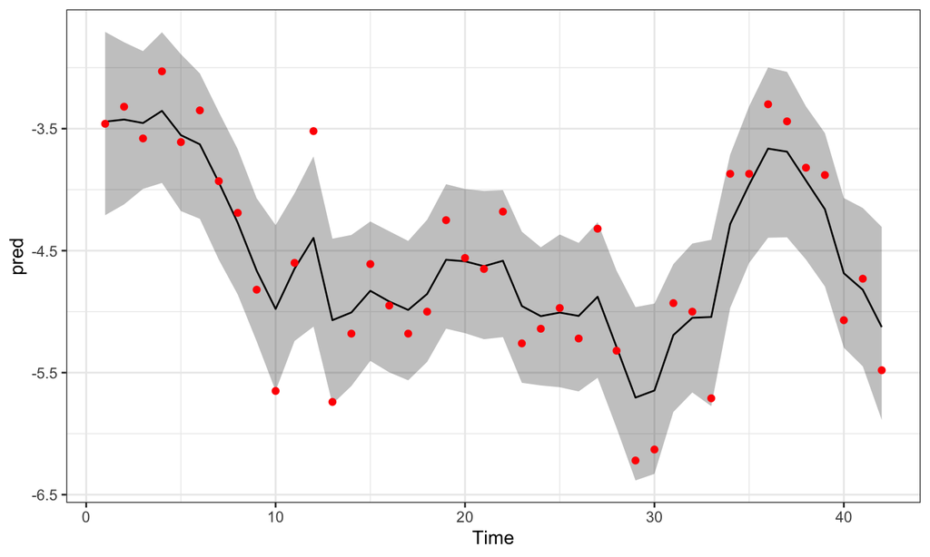

## Extra extensions

- `family` argument in `fit_stan` allows to have flexible families
- e.g., fit a Poisson or binomial DLM with

```r
mod = fit_stan(y = SalmonSurvCUI$logit.s,
               model_name="dlm-intercept",
               family="binomial")
mod = fit_stan(y = SalmonSurvCUI$logit.s,
               model_name="dlm-intercept",
               family="poisson")
```

## Summary

- Bayesian implementation of time series models in Stan can do everything that MARSS can do and more!
- Very flexible language, great developer community
- Widely used by students in SAFS / UW / QERM / etc
- Please come to us with questions, modeling issues, or add to code in our packages to make them better!